# What To Learn?

## Integral field Spectroscopy & Astronomical FITS Data cube(X,Y,Z) visualization

#### ***Integral Field Unit (IFU) spectroscopy is a powerful observational technique in astronomy that allows astronomers to obtain spectra(FLUX vs Wavelength) for every point (or small region) across a two-dimensional(X,Y) field of view***

#### 2. Where as Single slit spectroscopy (often just called slit spectroscopy) is a fundamental technique in astronomical and laboratory spectroscopy where light from a source passes through a narrow slit

#### 3D data cube:

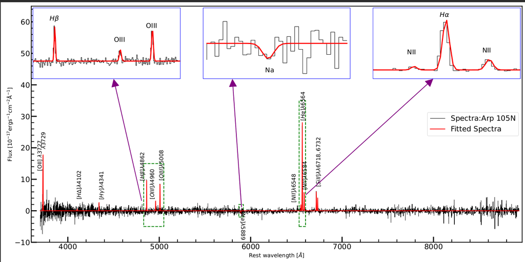

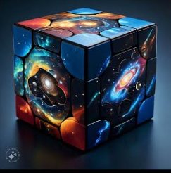

[figure not shown]

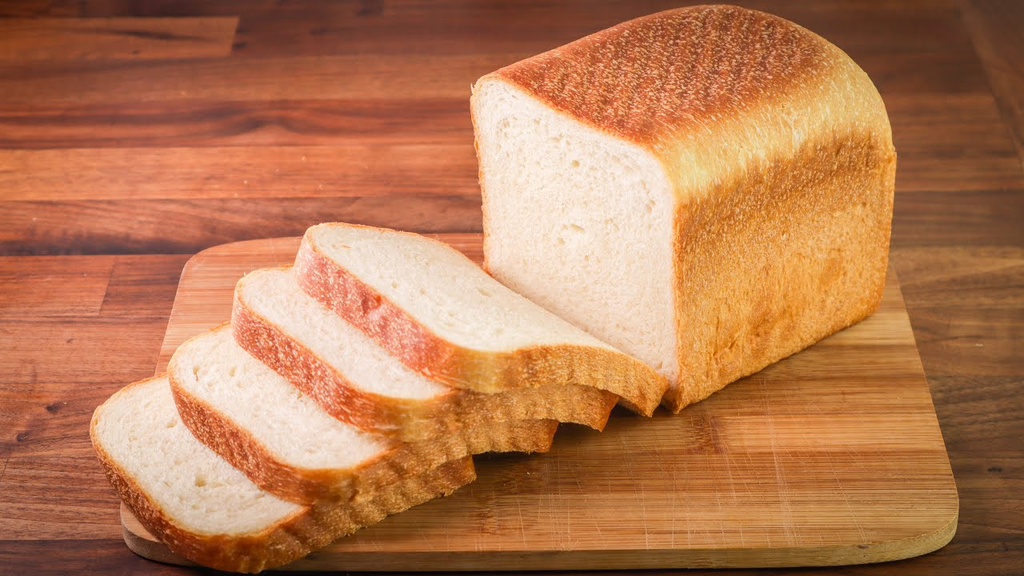

#### X and Y: Spatial dimensions (like an image) called "SPAXEL" or Spectral Pixel

#### Z: Spectral dimension (wavelength) λ

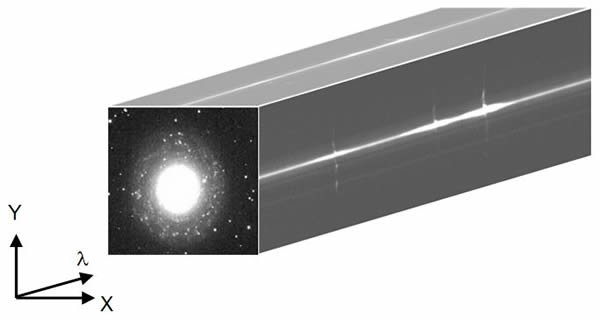

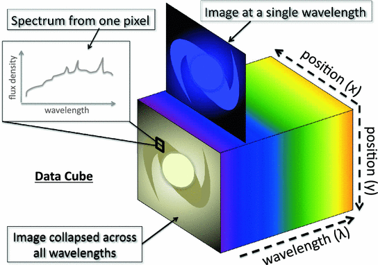

### ✅ Advantages of IFU Spectroscopy

### 1. Spatially Resolved Spectra

Each spaxel has a full spectrum → you get a data cube: (x, y, λ)

Allows you to study how physical properties change across an object (e.g., a galaxy)

E.g., You can map velocity, metallicity, star formation, and ionization across a galaxy, not just from a single line of sight.

### 2. No Need for Slit Alignment

In single-slit spectroscopy, precise alignment is critical

IFUs observe everything in the field of view at once → reduces pointing errors and losses

### 3. Efficient Use of Telescope Time

With a single pointing, you get multiple spectra across a region

Great for complex or extended sources (e.g., galaxies, nebulae, mergers)

#### Step-2: Import library

```python
%matplotlib widget
from astropy.io import fits
import numpy as np
import matplotlib.pyplot as plt
```

#### Step-3: Read FITS Data cube of Galaxy from SDSS MANGA survey

```python
cube=fits.open('manga-10215-1902-LINCUBE.fits')
```

#### Step-4: Extract FITS Cube information

```python
cube.info()
```

```
Filename: manga-10215-1902-LINCUBE.fits
No.    Name      Ver    Type      Cards   Dimensions   Format
  0  PRIMARY       1 PrimaryHDU      75   ()
  1  FLUX          1 ImageHDU       100   (34, 34, 6732)   float32
  2  IVAR          1 ImageHDU        17   (34, 34, 6732)   float32
  3  MASK          1 ImageHDU        17   (34, 34, 6732)   int32
  4  LSFPOST       1 ImageHDU        11   (34, 34, 6732)   float32
  5  LSFPRE        1 ImageHDU        11   (34, 34, 6732)   float32
  6  WAVE          1 ImageHDU         9   (6732,)   float64
  7  SPECRES       1 ImageHDU         9   (6732,)   float64
  8  SPECRESD      1 ImageHDU         9   (6732,)   float64
  9  PRESPECRES    1 ImageHDU         9   (6732,)   float64
 10  PRESPECRESD    1 ImageHDU         9   (6732,)   float64
 11  OBSINFO       1 BinTableHDU    148   12R x 65C   [26A, 17A, 5A, J, I, 8A, E, E, E, E, E, E, J, J, I, J, E, 12A, J, 8A, E, E, E, E, E, E, E, E, E, E, E, E, E, E, E, E, E, E, E, 13A, E, E, E, E, D, D, D, D, E, E, J, J, J, E, E, E, E, E, E, J, J, E, E, E, E]
 12  GIMG          1 ImageHDU        28   (34, 34)   float32
 13  RIMG          1 ImageHDU        28   (34, 34)   float32
 14  IIMG          1 ImageHDU        28   (34, 34)   float32
 15  ZIMG          1 ImageHDU        28   (34, 34)   float32
 16  GPSF          1 ImageHDU        28   (34, 34)   float32
 17  RPSF          1 ImageHDU        28   (34, 34)   float32
 18  IPSF          1 ImageHDU        28   (34, 34)   float32
 19  ZPSF          1 ImageHDU        28   (34, 34)   float32
 20  GCORREL       1 BinTableHDU     32   20876R x 5C   [J, J, J, J, D]
 21  RCORREL       1 BinTableHDU     32   22312R x 5C   [J, J, J, J, D]
 22  ICORREL       1 BinTableHDU     32   23421R x 5C   [J, J, J, J, D]
 23  ZCORREL       1 BinTableHDU     32   24252R x 5C   [J, J, J, J, D]
```

#### Step-5: Extract cube Data From HDUs: Flux, Wavelength, Flux error etc

```python
flux=cube['FLUX'].data
flux.shape

wave=cube['WAVE'].data
wave
```

```
array([ 3622.,  3623.,  3624., ..., 10351., 10352., 10353.], dtype='>f8')
```

#### Step-6: Visualize Galaxy flux map along Z: wavelength axis

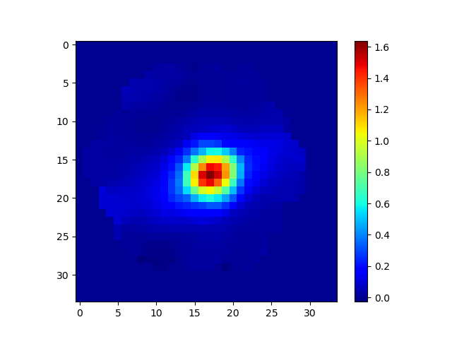

```python
plt.figure()
plt.imshow(flux[1000,:,:],cmap='jet') # [z,y,x]
plt.colorbar()
plt.show()
```

#### Step-7: Visualize Galaxy spectra at each spaxel(x,y) in observed frame

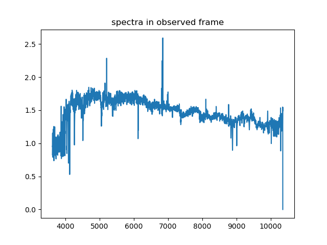

```python
plt.figure()
plt.plot(wave,flux[:,17,17])  #[full z,y,x]
plt.title('spectra in observed frame')
plt.show()
```